# Song Popularity

Sam DeMarinis and Nick Radwin

Link to our webpage: https://samdemarinis.github.io/

# Project Goals

The goal of this project is to understand what features of a song are strongly associated with high popularity in order to build an accurate model that predicts a given song's popularity. We will be incorporating datasets found online that have utilized Spotify's API as well as creating our own to see how a prediction for a song's popularity may change depending on the dataset used to build the model. Lastly, we will be utilizing Billboard Top 100 data before and after the COVID-19 pandemic to investigate how the importance of certain features of a song in predicting popularity may have changed from before/after the pandemic.

# Key Questions to Answer

- Where did the dataset we are utilizing come from? How was it obtained and how are the variables defined?
- How can we build an accurate model to predict a song's 'popularity' based off features such as 'name', 'album', 'artist', 'release_date', 'length', 'explicit', 'acousticness', 'danceability', 'energy', 'instrumentalness', 'liveness', 'loudness', 'speechiness', 'tempo', 'time_signature', 'key', 'mode', and 'valence'?
- What features provided by Spotify's API are the most important in predicting song popularity? And in contrast, which features hurt the model?
- How does the model that we built on the pre-packaged dataset "Spotify Tracks Dataset" compare to the model that we built on our own dataset?
- Is there a relationship between song popularity on Spotify and song popularity on the Billboard Top 100? Are we able to predict how many weeks a song will appear on the Billboard Top 100 Chart in a year?
- How has the importance of the above features changed in predicting a song's popularity pre- and 'post-' COVID-19?

# Spotify Tracks Dataset

The first dataset that we are working with is the Spotify Tracks Dataset available on Kaggle (https://www.kaggle.com/datasets/maharshipandya/-spotify-tracks-dataset). This dataset was constructed by the Kaggle user @MAHARSHIPANDYA in 2022 using Spotify's API. It contains almost 120,000 rows each corresponding to a song on Spotify. While the method for selecting the songs is not clearly stated, it can be assumed that it was a randomized process due to the large variety of songs. The columns of the dataset describe features of the songs, ranging from basic identifiers such as *track_id* and and *album_name* to more musical qualities such as *energy* and *danceability*. The full breakdown of what each variable entails can be found under the Column Description of the Spotify Tracks Dataset, linked above.

# Methods for Quantifiying Subjective Variables

The variable that we are initially interested in predicting is *popularity*. We will eventually build a model that will be fit to our training data and tested on subsets of our data. But how does one measure things like popularity, energy, or danceability? Spotify Web API describes how these seemingly subjective measures were calculated. Below is a list of the most subjective variables in the dataset and how they were calculated.

**popularity**: "The value will be between 0 and 100, with 100 being the most popular. The popularity of a track is a value between 0 and 100, with 100 being the most popular. The popularity is calculated by algorithm and is based, in the most part, on the total number of plays the track has had and how recent those plays are."

**danceability**: "Danceability describes how suitable a track is for dancing based on a combination of musical elements including tempo, rhythm stability, beat strength, and overall regularity. A value of 0.0 is least danceable and 1.0 is most danceable."

**energy**: "Energy is a measure from 0.0 to 1.0 and represents a perceptual measure of intensity and activity. Typically, energetic tracks feel fast, loud, and noisy. For example, death metal has high energy, while a Bach prelude scores low on the scale."

**speechiness**: "Speechiness detects the presence of spoken words in a track. The more exclusively speech-like the recording (e.g. talk show, audio book, poetry), the closer to 1.0 the attribute value. Values above 0.66 describe tracks that are probably made entirely of spoken words. Values between 0.33 and 0.66 describe tracks that may contain both music and speech, either in sections or layered, including such cases as rap music. Values below 0.33 most likely represent music and other non-speech-like tracks."

**liveness**: "Detects the presence of an audience in the recording. Higher liveness values represent an increased probability that the track was performed live. A value above 0.8 provides strong likelihood that the track is live."

**valence**: "A measure from 0.0 to 1.0 describing the musical positiveness conveyed by a track. Tracks with high valence sound more positive (e.g. happy, cheerful, euphoric), while tracks with low valence sound more negative (e.g. sad, depressed, angry)."

**mode**: "Mode indicates the modality (major or minor) of a track, the type of scale from which its melodic content is derived. Major is represented by 1 and minor is 0."

Now that we understand how these variables were quantified, we can properly assess their level of subjectivity. *popularity*, the label we will be initially predicting, is based on an algorithm involving a track's plays. This variable is not very subjective. However, variables like *danceability* and *valence* still contain some subjectivity. Knowing this and what it is we want to predict, we can begin extracting, transforming, and loading this dataset.

# Extracting, Transforming, and Loading: Spotify Tracks Dataset

First, we must mount our Google Drive and change the directory to our Drive.

```python
from google.colab import drive
import pandas as pd
import pylab as pl

drive.mount('/content/drive')
%cd /content/drive/My Drive
```

```
/content/drive/My Drive
```

Reading in the Spotify Tracks Datatset csv file and making a copy:

```python
spotify_df = pd.read_csv("dataset.csv")
spotify_df_copy = spotify_df.copy()
spotify_df_copy.head()
```

|  | Unnamed: 0 | track_id | artists | album_name | track_name | popularity | duration_ms | explicit | danceability | energy | ... | loudness | mode | speechiness | acousticness | instrumentalness | liveness | valence | tempo | time_signature | track_genre |
| --- | --- | --- | --- | --- | --- | --- | --- | --- | --- | --- | --- | --- | --- | --- | --- | --- | --- | --- | --- | --- | --- |
| 0 | 0 | 5SuOikwiRyPMVoIQDJUgSV | Gen Hoshino | Comedy | Comedy | 73 | 230666 | False | 0.676 | 0.4610 | ... | -6.746 | 0 | 0.1430 | 0.0322 | 0.000001 | 0.3580 | 0.715 | 87.917 | 4 | acoustic |
| 1 | 1 | 4qPNDBW1i3p13qLCt0Ki3A | Ben Woodward | Ghost (Acoustic) | Ghost - Acoustic | 55 | 149610 | False | 0.420 | 0.1660 | ... | -17.235 | 1 | 0.0763 | 0.9240 | 0.000006 | 0.1010 | 0.267 | 77.489 | 4 | acoustic |
| 2 | 2 | 1iJBSr7s7jYXzM8EGcbK5b | Ingrid Michaelson;ZAYN | To Begin Again | To Begin Again | 57 | 210826 | False | 0.438 | 0.3590 | ... | -9.734 | 1 | 0.0557 | 0.2100 | 0.000000 | 0.1170 | 0.120 | 76.332 | 4 | acoustic |
| 3 | 3 | 6lfxq3CG4xtTiEg7opyCyx | Kina Grannis | Crazy Rich Asians (Original Motion Picture Sou... | Can't Help Falling In Love | 71 | 201933 | False | 0.266 | 0.0596 | ... | -18.515 | 1 | 0.0363 | 0.9050 | 0.000071 | 0.1320 | 0.143 | 181.740 | 3 | acoustic |
| 4 | 4 | 5vjLSffimiIP26QG5WcN2K | Chord Overstreet | Hold On | Hold On | 82 | 198853 | False | 0.618 | 0.4430 | ... | -9.681 | 1 | 0.0526 | 0.4690 | 0.000000 | 0.0829 | 0.167 | 119.949 | 4 | acoustic |

5 rows × 21 columns

The dataset already seems to be pretty tidy, but there is some more tidying to be done. There is an extra column with no purpose, so we can go ahead and remove it:

```python
spotify_df_copy.drop(columns=["Unnamed: 0"], inplace=True)
```

We should always check the dtypes for each of our variables. Pandas may misinterpret certain variables as categorical instead of quanitative, or vice versa. Luckily, we can see that Pandas correctly interpreted the dtype for each variable in our DataFrame:

```python
spotify_df_copy.dtypes
```

```
track_id             object
artists              object
album_name           object
track_name           object
popularity            int64
duration_ms           int64
explicit               bool
danceability        float64
energy              float64
key                   int64
loudness            float64
mode                  int64
speechiness         float64
acousticness        float64
instrumentalness    float64
liveness            float64
valence             float64
tempo               float64
time_signature        int64
track_genre          object
dtype: object
```

We should also check for duplicate and NaN values in our DataFrame:

```python
spotify_df_copy.duplicated().sum()
```

```
450
```

```python
spotify_df_copy.isnull().sum().sum()
```

```
3
```

We can now drop the duplicate rows and rows containing NaNs:

```python
spotify_df_copy.drop_duplicates(inplace=True)
spotify_df_copy.dropna(inplace=True)
spotify_df_copy.head()
```

|  | track_id | artists | album_name | track_name | popularity | duration_ms | explicit | danceability | energy | key | loudness | mode | speechiness | acousticness | instrumentalness | liveness | valence | tempo | time_signature | track_genre |
| --- | --- | --- | --- | --- | --- | --- | --- | --- | --- | --- | --- | --- | --- | --- | --- | --- | --- | --- | --- | --- |
| 0 | 5SuOikwiRyPMVoIQDJUgSV | Gen Hoshino | Comedy | Comedy | 73 | 230666 | False | 0.676 | 0.4610 | 1 | -6.746 | 0 | 0.1430 | 0.0322 | 0.000001 | 0.3580 | 0.715 | 87.917 | 4 | acoustic |
| 1 | 4qPNDBW1i3p13qLCt0Ki3A | Ben Woodward | Ghost (Acoustic) | Ghost - Acoustic | 55 | 149610 | False | 0.420 | 0.1660 | 1 | -17.235 | 1 | 0.0763 | 0.9240 | 0.000006 | 0.1010 | 0.267 | 77.489 | 4 | acoustic |
| 2 | 1iJBSr7s7jYXzM8EGcbK5b | Ingrid Michaelson;ZAYN | To Begin Again | To Begin Again | 57 | 210826 | False | 0.438 | 0.3590 | 0 | -9.734 | 1 | 0.0557 | 0.2100 | 0.000000 | 0.1170 | 0.120 | 76.332 | 4 | acoustic |
| 3 | 6lfxq3CG4xtTiEg7opyCyx | Kina Grannis | Crazy Rich Asians (Original Motion Picture Sou... | Can't Help Falling In Love | 71 | 201933 | False | 0.266 | 0.0596 | 0 | -18.515 | 1 | 0.0363 | 0.9050 | 0.000071 | 0.1320 | 0.143 | 181.740 | 3 | acoustic |
| 4 | 5vjLSffimiIP26QG5WcN2K | Chord Overstreet | Hold On | Hold On | 82 | 198853 | False | 0.618 | 0.4430 | 2 | -9.681 | 1 | 0.0526 | 0.4690 | 0.000000 | 0.0829 | 0.167 | 119.949 | 4 | acoustic |

Our DataFrame is now in great shape for analysis. An important note to make is that, while we requested for Pandas to drop duplicate rows (or tracks) in our DataFrame, there are still multiple rows that are the same song. This is due to the fact that some songs are listed as being in more than one genre, and for each genre they fall into they are entered another time into the dataset. Pandas does not interpret these rows as being duplicates because they differ on the *track_genre* variable. To see this, let's look up all rows that have a specific *track_id*:

```python
spotify_df_copy[(spotify_df_copy['track_id'] == "2QjOHCTQ1Jl3zawyYOpxh6")]
```

|  | track_id | artists | album_name | track_name | popularity | duration_ms | explicit | danceability | energy | key | loudness | mode | speechiness | acousticness | instrumentalness | liveness | valence | tempo | time_signature | track_genre |
| --- | --- | --- | --- | --- | --- | --- | --- | --- | --- | --- | --- | --- | --- | --- | --- | --- | --- | --- | --- | --- |
| 2003 | 2QjOHCTQ1Jl3zawyYOpxh6 | The Neighbourhood | I Love You. | Sweater Weather | 93 | 240400 | False | 0.612 | 0.807 | 10 | -2.81 | 1 | 0.0336 | 0.0495 | 0.0177 | 0.101 | 0.398 | 124.053 | 4 | alt-rock |
| 3003 | 2QjOHCTQ1Jl3zawyYOpxh6 | The Neighbourhood | I Love You. | Sweater Weather | 93 | 240400 | False | 0.612 | 0.807 | 10 | -2.81 | 1 | 0.0336 | 0.0495 | 0.0177 | 0.101 | 0.398 | 124.053 | 4 | alternative |
| 81853 | 2QjOHCTQ1Jl3zawyYOpxh6 | The Neighbourhood | I Love You. | Sweater Weather | 93 | 240400 | False | 0.612 | 0.807 | 10 | -2.81 | 1 | 0.0336 | 0.0495 | 0.0177 | 0.101 | 0.398 | 124.053 | 4 | pop |
| 91002 | 2QjOHCTQ1Jl3zawyYOpxh6 | The Neighbourhood | I Love You. | Sweater Weather | 93 | 240400 | False | 0.612 | 0.807 | 10 | -2.81 | 1 | 0.0336 | 0.0495 | 0.0177 | 0.101 | 0.398 | 124.053 | 4 | rock |

Let's investigate this table before we start constructing a model. Since we are interested in analyzing and eventually creating a model to predict the *popularity* of a song, let's look up songs with a popularity rating greater than 90:

```python
# let's look at songs with high popularity:
spotify_df_copy["popularity"].unique()
popular_songs = spotify_df_copy[(spotify_df_copy["popularity"]  >= 90)]["track_id"].unique()
popular_songs
```

```
array(['2QjOHCTQ1Jl3zawyYOpxh6', '3JvKfv6T31zO0ini8iNItO',
       '5IgjP7X4th6nMNDh4akUHb', '3nqQXoyQOWXiESFLlDF1hG',
       '4uUG5RXrOk84mYEfFvj3cK', '0mBP9X2gPCuapvpZ7TGDk3',
       '0hquQWY3xvYqN4qtiquniF', '4C6Uex2ILwJi9sZXRdmqXp',
       '4zN21mbAuaD0WqtmaTZZeP', '1xzi1Jcr7mEi9K2RfzLOqS',
       '1Fid2jjqsHViMX6xNH70hE', '5XeFesFbtLpXzIVDNQP22n',
       '3F5CgOj3wFlRv51JsHbxhe', '38T0tPVZHcPZyhtOcCP7pF',
       '2tTmW7RDtMQtBk7m2rYeSw', '5ww2BF9slyYgNOk37BlC4u',
       '6Sq7ltF9Qa7SNFBsV5Cogx', '1IHWl5LamUGEuP4ozKQSXZ',
       '3k3NWokhRRkEPhCzPmV8TW', '5Eax0qFko2dh7Rl2lYs3bx',
       '2rurDawMfoKP4uHyb2kJBt', '6Xom58OOXk2SoU711L2IXO',
       '31i56LZnwE6uSu3exoHjtB', '79HZAZNnOE97rb2hnI0XQr',
       '41oY4WCTj5kccfesTVFnvN', '6i1g5ZRmJZAkDwBaUZ3f2i',
       '4tYFy8ALRjIZvnvSLw5lxN', '1797zYiX4cKosMH836X9Gt',
       '4h9wh7iOZ0GGn8QVp4RAOB', '75FEaRjZTKLhTrFGsfMUXR',
       '0VjIjW4GlUZAMYd2vXMi3b', '7MXVkk9YMctZqd1Srtv4MB',
       '58HvfVOeJY7lUuCqF0m3ly', '2eAvDnpXP5W0cVtiI0PUxV',
       '0T5iIrXA4p5GsubkhuBIKV', '4LRPiXqCikLlN15c3yImP7',
       '0WtM2NBVQNNJLh6scP13H8', '1cKHdTo9u0ZymJdPGSh6nq',
       '6xGruZOHLs39ZbVccQTuPZ', '4Dvkj6JhhA12EX05fT7y2e',
       '7dSZ6zGTQx66c2GF91xCrb', '1ga4PztXOIw1yBbdUt2X8v',
       '7DbdUf8aHSYoliSjO6LZv6'], dtype=object)
```

Let's say that we are interested in looking at the *energy* of these popular songs, and if there is a common trend for this variable:

```python
# let's look at the energy of these songs:
energy_list = []

for i in popular_songs:
  x = spotify_df_copy[(spotify_df_copy['track_id'] == i)]["energy"].iloc[0]
  energy_list.append(x)

data = {'track_id':popular_songs,
        'Energy':energy_list,
        }

df_pop_energy = pd.DataFrame(data, index=range(0,43))
df_pop_energy.head()
```

|  | track_id | Energy |
| --- | --- | --- |
| 0 | 2QjOHCTQ1Jl3zawyYOpxh6 | 0.807 |
| 1 | 3JvKfv6T31zO0ini8iNItO | 0.537 |
| 2 | 5IgjP7X4th6nMNDh4akUHb | 0.690 |
| 3 | 3nqQXoyQOWXiESFLlDF1hG | 0.472 |
| 4 | 4uUG5RXrOk84mYEfFvj3cK | 0.965 |

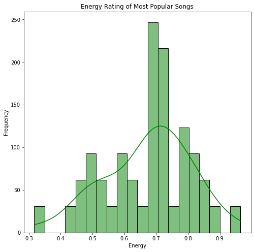

```python
import seaborn as sns
import matplotlib.pyplot as plt

fig, ax = plt.subplots(figsize=(8, 8))

sns.histplot(data=df_pop_energy, x='Energy', color='green', bins=20, stat='frequency', kde=True).set(title='Energy Rating of Most Popular Songs')
plt.show()
```

From the histogram alone, we can see that the most common energy rating among the most popular songs in the dataset was around 0.7 out of 1.

Now, let's take a look at the most common genres of the most popular songs:

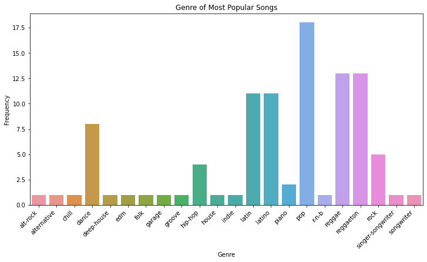

```python
popular_songs_df = spotify_df_copy[(spotify_df_copy["popularity"]  >= 90)]

fig, ax = plt.subplots(figsize=(12, 6))
plot2 = sns.countplot(data=popular_songs_df, x='track_genre', ax=ax).set(title='Genre of Most Popular Songs', xlabel='Genre', ylabel='Frequency')
ax.set_xticklabels(ax.get_xticklabels(), rotation=45, horizontalalignment='right')
plt.show()
```

We can now see the distribution of genres among the most popular songs. Unsurprisingly, the most common genre of the most popular songs is pop.

# Creating a Predictive Model for Song Popularity

Now that we have looked at some of the summary statistics for this dataset, let's begin constructing a predictive model. We will use the machine learning algorithm of k-nearest neighbors regression and determine which value of k results in the lowest mean absolute error.

**Hyperparameter Tuning**

To predict how popular a song may be depending on its features, we will build a k-nearest neighbors model. Let's determine the best k value (number of neighbors) for our model (we left hyperparameter tuning out of this milestone because it takes too long to run, but we will keep tweaking to take in less data to get an Mean Standard Error graph to print showing the best k value):

```python
from sklearn.feature_extraction import DictVectorizer
from sklearn.preprocessing import StandardScaler
from sklearn.neighbors import KNeighborsRegressor
from sklearn.pipeline import Pipeline
import numpy as np
from sklearn.model_selection import cross_val_score
```

**5-Nearest Neighbor Predictive Model:**

```python
# define the training data
X_train = spotify_df_copy[[
            "danceability",
            "energy",
            "loudness",
            "speechiness",
            "instrumentalness",
            "time_signature"
            ]]

y_train = spotify_df_copy["popularity"]

# standardize the data
scaler = StandardScaler()
scaler.fit(X_train)
X_train_sc = scaler.transform(X_train)

# fit the 9-nearest neighbors model
model = KNeighborsRegressor(n_neighbors=5)
model.fit(X_train_sc, y_train)

# define the test data (Scikit-Learn expects a matrix)
x_new = pd.DataFrame()

x_new["danceability"] = [0.420]
x_new["energy"] = [0.166]
x_new["loudness"] = [-17.235]
x_new["speechiness"] = [0.0763]
x_new["instrumentalness"] = [0.000006]
x_new["time_signature"] = [4]

x_new_sc = scaler.transform(x_new)

# use the model to predict on the test data
model.predict(x_new_sc)

#model.kneighbors(x_new_sc, n_neighbors=15)
#print(model.kneighbors(x_new_sc, n_neighbors=15))
```

```
array([42.])
```

The song with these feature values, which are all statistically significant, has a true popularity of 55/100. However, our model predicts that this song would have a popularity of about 42/100. This disparity indicates that we may need to tweak our model a bit to get more accurate popularity predictions. Although, there may be external factors to our data such as the historical context around a song's release that accounts for the disparity.

# Creating Our Own Dataset Using Spotipy

We have just created a predictive model for song popularity based on the Spotify Tracks Dataset. Now, we are interested in constructing our own dataset to see how varying sources of data describing the same units of observation and features can result in more/less accurate predictive models. In order to build our own dataset of Spotify data, we must use Spotify's API.

A popular Python library for the Spotify Web API is called Spotipy. We will be utilizing this library because it is easy to unerstand and allows us to demonstrate commands in this notebook.

```python
# installing spotipy
!pip install urllib3
!pip install requests
!pip install spotipy
```

[output not shown]

```python
from fastai.collab import *
from fastai.tabular import *
import pandas as pd
import numpy as np
import spotipy
import spotipy.util as util
from spotipy.oauth2 import SpotifyClientCredentials
import spotipy.oauth2 as oauth2
from spotipy.oauth2 import SpotifyOAuth
```

In order to make calls to Spotify's API using spotipy, we must register a Spotify account as a Developer. We will then create an Application, obtain our Client ID and Secret, and enter in a specific Redirect URI.

```python
# Sam's Spotify credentials

CLIENT_ID = "92f8907c269f4703917254ec2454f4c7"
CLIENT_SECRET = "fea4962791dd466d840feba0e11a11df"
username = "sam7303"
market = ['US']
redirect_uri = 'http://127.0.0.1:9090'
scope="user-library-read"
```

Now that we have our credentials stored into variables, we can create a Spotipy object that authorizes us as a valid Developer:

```python
# creating spotipy object

sp = spotipy.Spotify(auth_manager=SpotifyOAuth(client_id=CLIENT_ID,
                                               client_secret=CLIENT_SECRET,
                                               redirect_uri=redirect_uri,
                                               scope="user-library-read", open_browser=False))
```

We are interested in understanding what features may be indicative of a song's popularity at this point in time. Every few days, Spotify updates the playlist "Today's Top Hits" to contain the top 50 most played songs on Spotify. This is a good indication that a song is popular. We will be analyzing the features of the songs in the playlist over the course of a few weeks so that we can see the breakdown of the features.

We can obtain the playlist ID by looking at the end of its URL. Next, we can access each of the tracks in the playlist with the command below:

(Note: The code below will fetch the most *recent* songs in the "Today's Top Hits" playlist. The returned song data depends on when the code is run.)

```python
# "Today's Top Hits" playlist -- 50 of the most popular songs

PLAYLIST_ID = '37i9dQZF1DXcBWIGoYBM5M'
playlist_tracks = sp.user_playlist_tracks(CLIENT_ID, PLAYLIST_ID, fields='items,uri,name,id,total')
```

Now, we can find the song ID for each song in this playlist. This will allow us to then access the desired features for each song and create a dataset.

```python
songIDs = []

for i in range(len(playlist_tracks['items'])):
  songIDs.append(playlist_tracks['items'][i]['track']['id'])

print(songIDs)
len(songIDs)
```

```
['1bDbXMyjaUIooNwFE9wn0N', '3nqQXoyQOWXiESFLlDF1hG', '0V3wPSX9ygBnCm8psDIegu', '4LRPiXqCikLlN15c3yImP7', '1xzi1Jcr7mEi9K2RfzLOqS', '4uUG5RXrOk84mYEfFvj3cK', '73vIOb4Q7YN6HeJTbscRx5', '0WtM2NBVQNNJLh6scP13H8', '4h9wh7iOZ0GGn8QVp4RAOB', '18zQTt3ifDv6iLni2YuXMg', '0QHEIqNKsMoOY5urbzN48u', '5jQI2r1Rdgtu…
```

```
50
```

We can utilize the track() function provided by Spotipy to access important information and features about each song. For example, the following code accesses a few of these features for a specific song:

```python
track_info = sp.track("0V3wPSX9ygBnCm8psDIegu")
track_features = sp.audio_features('0V3wPSX9ygBnCm8psDIegu')

# some important info
name = track_info['name']
album = track_info['album']['name']

# some important features
acousticness = track_features[0]['acousticness']
danceability = track_features[0]['danceability']

print(f'Song name: {name}')
print(f'Album: {album}')
print(f'Acousticness: {acousticness}')
print(f'Danceability: {danceability}')
```

```
Song name: Anti-Hero
Album: Midnights
Acousticness: 0.13
Danceability: 0.637
```

Now, we will follow these steps for each of the songs in the "Today's Top Hits" playlist. We will define a function that will give a list of track features given a song ID, and then call that function on each song ID in the songIDs list so that we can construct a DataFrame.

```python
def getTrackFeatures(songID):

  track_info = sp.track(songID)
  track_features = sp.audio_features(songID)

  name = track_info['name']
  album = track_info['album']['name']
  artist = track_info['album']['artists'][0]['name']
  release_date = track_info['album']['release_date']
  length = track_info['duration_ms']
  popularity = track_info['popularity']
  explicit = track_info['explicit']
  #genre = track_info['genre']
  # currently, spotify does not list the specific genre a track falls in. instead it offers the genres associated to the artist

  acousticness = track_features[0]['acousticness']
  danceability = track_features[0]['danceability']
  energy = track_features[0]['energy']
  instrumentalness = track_features[0]['instrumentalness']
  liveness = track_features[0]['liveness']
  loudness = track_features[0]['loudness']
  speechiness = track_features[0]['speechiness']
  tempo = track_features[0]['tempo']
  time_signature = track_features[0]['time_signature']
  key = track_features[0]["key"]
  mode = track_features[0]["mode"]
  valence = track_features[0]["valence"]

  track_features_list = [name, album, artist, release_date, length, popularity, explicit, acousticness, danceability, energy,
                         instrumentalness, liveness, loudness, speechiness, tempo, time_signature, key, mode, valence]
  return track_features_list
```

Inspiration for this function was found here: https://levelup.gitconnected.com/extracting-and-analysing-spotify-tracks-with-python-d1466fc1dfee

```python
# XXX refers to the current month, day, and year in which you run the code

df_top_hits_XXX = pd.DataFrame(columns=['name', 'album', 'artist', 'release_date', 'length', 'popularity', 'explicit', 'acousticness',
                                            'danceability', 'energy', 'instrumentalness', 'liveness', 'loudness', 'speechiness',
                                           'tempo', 'time_signature', 'key', 'mode', 'valence'])

for id in songIDs:
  track_list = getTrackFeatures(id)
  df = pd.DataFrame(data=[track_list], columns=['name', 'album', 'artist', 'release_date', 'length', 'popularity', 'explicit', 'acousticness',
                                            'danceability', 'energy', 'instrumentalness', 'liveness', 'loudness', 'speechiness',
                                           'tempo', 'time_signature', 'key', 'mode', 'valence'])

  df_top_hits_XXX = pd.concat([df_top_hits_XXX, df], ignore_index=True)

df_top_hits_XXX.head()
```

|  | name | album | artist | release_date | length | popularity | explicit | acousticness | danceability | energy | instrumentalness | liveness | loudness | speechiness | tempo | time_signature | key | mode | valence |
| --- | --- | --- | --- | --- | --- | --- | --- | --- | --- | --- | --- | --- | --- | --- | --- | --- | --- | --- | --- |
| 0 | Rich Flex | Her Loss | Drake | 2022-11-04 | 239359 | 92 | True | 0.0503 | 0.561 | 0.520 | 0.000002 | 0.3550 | -9.342 | 0.2440 | 153.150 | 3 | 11 | 0 | 0.424 |
| 1 | Unholy (feat. Kim Petras) | Unholy (feat. Kim Petras) | Sam Smith | 2022-09-22 | 156943 | 100 | False | 0.0130 | 0.714 | 0.472 | 0.000005 | 0.2660 | -7.375 | 0.0864 | 131.121 | 4 | 2 | 1 | 0.238 |
| 2 | Anti-Hero | Midnights | Taylor Swift | 2022-10-21 | 200690 | 97 | False | 0.1300 | 0.637 | 0.643 | 0.000002 | 0.1420 | -6.571 | 0.0519 | 97.008 | 4 | 4 | 1 | 0.533 |
| 3 | As It Was | As It Was | Harry Styles | 2022-03-31 | 167303 | 93 | False | 0.3420 | 0.520 | 0.731 | 0.001010 | 0.3110 | -5.338 | 0.0557 | 173.930 | 4 | 6 | 0 | 0.662 |
| 4 | CUFF IT | RENAISSANCE | Beyoncé | 2022-07-29 | 225388 | 93 | True | 0.0368 | 0.780 | 0.689 | 0.000010 | 0.0698 | -5.668 | 0.1410 | 115.042 | 4 | 7 | 1 | 0.642 |

In order to keep the data used in the beginning of this tutorial constant, let's read in data previously obtained by performing these same steps on November 7, 2022:

```python
df_top_hits_110722 = pd.read_csv('df_top_hits_110722.csv')
```

```python
df_top_hits_110722.drop(columns=["Unnamed: 0"], inplace=True)
df_top_hits_110722.head()
```

|  | name | album | artist | release_date | length | popularity | explicit | acousticness | danceability | energy | instrumentalness | liveness | loudness | speechiness | tempo | time_signature | key | mode | valence |
| --- | --- | --- | --- | --- | --- | --- | --- | --- | --- | --- | --- | --- | --- | --- | --- | --- | --- | --- | --- |
| 0 | Anti-Hero | Midnights | Taylor Swift | 2022-10-21 | 200690 | 96 | False | 0.13000 | 0.637 | 0.643 | 0.000002 | 0.1420 | -6.571 | 0.0519 | 97.008 | 4 | 4 | 1 | 0.533 |
| 1 | Unholy (feat. Kim Petras) | Unholy (feat. Kim Petras) | Sam Smith | 2022-09-22 | 156943 | 100 | False | 0.01300 | 0.714 | 0.472 | 0.000005 | 0.2660 | -7.375 | 0.0864 | 131.121 | 4 | 2 | 1 | 0.238 |
| 2 | Shirt | Shirt | SZA | 2022-10-28 | 181830 | 87 | True | 0.14600 | 0.824 | 0.453 | 0.027300 | 0.0896 | -9.604 | 0.0968 | 119.959 | 4 | 3 | 0 | 0.552 |
| 3 | As It Was | As It Was | Harry Styles | 2022-03-31 | 167303 | 93 | False | 0.34200 | 0.520 | 0.731 | 0.001010 | 0.3110 | -5.338 | 0.0557 | 173.930 | 4 | 6 | 0 | 0.662 |
| 4 | I'm Good (Blue) | I'm Good (Blue) | David Guetta | 2022-08-26 | 175238 | 97 | True | 0.00383 | 0.561 | 0.965 | 0.000007 | 0.3710 | -3.673 | 0.0343 | 128.040 | 4 | 7 | 0 | 0.304 |

Saving the DataFrame we just created; exporting DataFrame as a csv file:

```python
#df_top_hits_XXX.to_csv('df_top_hits_111522.csv')
```

Let's analyze this DataFrame containing the 50 most popular songs on Spotify as of 11/07/22. Unsurprisingly, most of these songs have a high popularity rating:

```python
pop_median = df_top_hits_110722["popularity"].median()
pop_mean = df_top_hits_110722["popularity"].mean()
pop_min = df_top_hits_110722["popularity"].min()
pop_max = df_top_hits_110722["popularity"].max()

print(f"Median popularity: {pop_median}")
print(f"Mean popularity: {pop_mean}")
print(f"Highest popularity: {pop_max}")
print(f"Lowest popularity: {pop_min}")
```

```
Median popularity: 88.0
Mean popularity: 85.38
Highest popularity: 100
Lowest popularity: 11
```

In order to understand the 'typical' values for each feature of these top songs, let's do some summary statistics for all variables. This will look a bit different for categorical versus quantitative variables.

```python
df_top_hits_110722['artist'].value_counts()[:10]
```

```
Taylor Swift       2
Doja Cat           2
Various Artists    2
Lizzo              2
Harry Styles       2
Steve Lacy         1
Elton John         1
Charlie Puth       1
Måneskin           1
Zach Bryan         1
Name: artist, dtype: int64
```

Let's calculate the mean for each of our variables to see the typical values among these most popular songs. Conveniently, Pandas allows us to use the mean() function on the entire DataFrame and it will broadcast it across each column.

```python
df_typicals_110722 = df_top_hits_110722.drop(columns=["name", "album", "artist", "release_date", "explicit"]).mean()
df_typicals_110722
```

```
length              186319.880000
popularity              85.380000
acousticness             0.260349
danceability             0.687700
energy                   0.641760
instrumentalness         0.016821
liveness                 0.176996
loudness                -6.083040
speechiness              0.077904
tempo                  126.789360
time_signature           3.880000
key                      5.060000
mode                     0.660000
valence                  0.543212
dtype: float64
```

You may have noticed that it doesn't make much sense to find the mean of the *explicit* variable. This is due to the fact that it is a categorical variable as opposed to quantitative like the rest. To find out if there are more explicit or non-explicit songs in the playlist, we can use value_counts() on this variable.

```python
df_top_hits_110722["explicit"].value_counts().idxmax()

# False -- there are more non-explicit than explicit songs!
```

```
False
```

The goal is to collect data from the "Today's Top Hits" playlist throughout the coming weeks in order to construct a singular DataFrame containing more rows. This way, we can build a predictive model for popularity that can be compared to the one that we built off of the Spotify Tracks Dataset. We will then be able to make conclusions about the importance of certain features in predicting popularity, what values of k minimizes mean absolute error in our KNeighborsRegressor model, and more.

# Song Popularity: Before and After the COVID-19 Pandemic

Now that we have learned how to pull data from Spotify using their API, translate that data into a pandas DataFrame, perform summary statistics, and create predictive models using k-nearest neighbors linear regression, we will now use these skills to answer the final question listed at the start of this notebook:

**How has the importance of the above features changed in predicting a song's popularity pre and 'post' COVID-19?**

In order to answer this question, we will be looking at Billboard Top 100 data pre- and post-pandemic. We will use Spotify's API to access the same song features that we have been working with so far, but this time for those in the Top 100 list. We will create two DataFrames––one containing songs on the Billboard charts *before* the pandemic and one containing songs on the Billboard charts today ('*after*' the pandemic). We will then build two predictive models––one on the first DataFrame and one on the second––in order to assess the importance of each feature in predicting song popularity. This will be done by determining whether or not the p-value for each feature's weight is statistically significant to the prediciton.

# Step 1: Collecting Pre- and Post-Pandemic Billboard Top 100 Chart Data

We can load up a csv file of all Billboard Top 100 Chart data since the year 1956 with the following command:

```python
url = "https://raw.githubusercontent.com/HipsterVizNinja/random-data/main/Music/hot-100/Hot%20100.csv"
billboard_df = pd.read_csv(url)
```

We will first downselect this data to only contain song content from the year 2019. This will act as our 'pre-pandemic' dataset. One thing to keep in mind is that this dataset, like the Spotify Tracks Dataset, contains multiple entries of the same songs depending on how many weeks they were in the Top 100. In order to have each song only be entered once, we will need to create a column that lists the number of times each song was entered into the dataset (i.e., how many weeks it was in the Top 100 during 2019).

```python
# downselecting for 2019 songs
billboard_df_2019 = billboard_df[(billboard_df["chart_date"].str.startswith("2019"))]
billboard_df_2019 = billboard_df_2019.sort_values(by=['song'])
# need to sort the df so it is in the order of the value_counts series

# finding number of times each song appears on the charts in 2019
longevity_series = billboard_df_2019["song"].value_counts()

# making every song only appear once
billboard_df_2019 = billboard_df_2019.drop_duplicates(subset=['song'])

# list of each song and how many times it was on the charts in 2019
longevity_series
```

```
Dancing With A Stranger                          45
Wow.                                             44
Sunflower (Spider-Man: Into The Spider-Verse)    44
Talk                                             43
Old Town Road                                    42
                                                 ..
London Boy                                        1
Lord Above                                        1
Love Me                                           1
Love Me Anyway                                    1
whoa (mind in awe)                                1
Name: song, Length: 621, dtype: int64
```

Now that we have stored these numbers for each of the songs in this dataset into a variable *longevity_series*, we can sort the DataFrame to match up with this ordering:

```python
from pandas.api.types import CategoricalDtype

# sorting the dataframe to match the order of the longevity_series
cat_song_order = CategoricalDtype(
    longevity_series.index,
    ordered=True
)

billboard_df_2019['song'] = billboard_df_2019['song'].astype(cat_song_order)
billboard_df_2019 = billboard_df_2019.sort_values('song')

# creating variables of the desired order for songs and artists
desired_song_order_list = billboard_df_2019["song"].values
desired_artist_order_list = billboard_df_2019["performer"].values
```

We have also stored the correct ordering of the songs into a variable called *desired_song_order_list*. Not only does this give us the desired order for the songs in our DataFrame, it can be easily used with Spotify's API to get track information for each song in the list.

```python
billboard_df_2019.head() # 2019 billboard data, now in order of most to least # of times on Chart in 2019
```

|  | chart_position | chart_date | song | performer | song_id | instance | time_on_chart | consecutive_weeks | previous_week | peak_position | worst_position | chart_debut | chart_url |
| --- | --- | --- | --- | --- | --- | --- | --- | --- | --- | --- | --- | --- | --- |
| 58401 | 22 | 2019-08-24 | Dancing With A Stranger | Sam Smith & Normani | Dancing With A StrangerSam Smith & Normani | 1.0 | 31 | 30.0 | 20.0 | 7 | 41 | 2019-01-26 | https://www.billboard.com/charts/hot-100/2019-08-24 |
| 324913 | 23 | 2019-08-17 | Wow. | Post Malone | Wow.Post Malone | 1.0 | 33 | 32.0 | 20.0 | 2 | 47 | 2019-01-05 | https://www.billboard.com/charts/hot-100/2019-08-17 |
| 262779 | 19 | 2019-10-26 | Sunflower (Spider-Man: Into The Spider-Verse) | Post Malone & Swae Lee | Sunflower (Spider-Man: Into The Spider-Verse)Post Malone & Swae Lee | 1.0 | 52 | 51.0 | 18.0 | 1 | 24 | 2018-11-03 | https://www.billboard.com/charts/hot-100/2019-10-26 |
| 268591 | 44 | 2019-02-23 | Talk | Khalid | TalkKhalid | 1.0 | 1 | NaN | NaN | 44 | 44 | 2019-02-23 | https://www.billboard.com/charts/hot-100/2019-02-23 |
| 204800 | 10 | 2019-09-28 | Old Town Road | Lil Nas X Featuring Billy Ray Cyrus | Old Town RoadLil Nas X Featuring Billy Ray Cyrus | 1.0 | 29 | 28.0 | 11.0 | 1 | 83 | 2019-03-16 | https://www.billboard.com/charts/hot-100/2019-09-28 |

We can see with the command below that we hope to obtain information on 621 songs.

```python
# we have 621 songs we'd like to get spotify api info on
len(desired_song_order_list)
```

```
621
```

Let's iterate through each song in this list and attempt to fetch song IDs.

```python
# using spotify's api to get this info

track_id_list = []

for track in desired_song_order_list:
  try:
    track_json = sp.search(q='track:' + track, type='track')
    track_id = track_json['tracks']['items'][0]['id']
    track_id_list.append(track_id)
  except IndexError:
    track_id = "N/A"
    print(track)
```

```
Can't Leave Without It
Don't Check On Me
```

We can see that we were unable to fetch the song ID for two songs: "Can't Leave Without It" and "Don't Check On Me." We can remove these from the *longevity_series* variable so that we can eventually add this Series to our DataFrame, and it will accurately indicate how many times each song appeared on the Charts in 2019.

(If we did not remove these songs from the Series and simply added the Series to the DataFrame we are about to create, the values would not line up correctly with each song because we will only be able to make a DataFrame of 619 songs).

Let's drop these two songs from *longevity_series*, checking the length of the series before and after to make sure we actually got rid of them:

```python
print(len(longevity_series))
longevity_series = longevity_series.drop(labels=["Can't Leave Without It", "Don't Check On Me"])
print(len(longevity_series))
```

```
621
619
```

We are now ready to utilize Spotify's API to make a DataFrame called *df_billboard_2019*. This DataFrame will contain each song that appeared on the Billboard Top 100 in 2019 and the exact same features we have been looking at since the beginning of this tutorial. We can use the *getTrackFeatures()* function that we previously made to easily fetch all of this track information.

```python
# creating a dataframe for the spotify api info on each of these songIDs
df_billboard_2019 = pd.DataFrame(columns=['name', 'album', 'artist', 'release_date', 'length', 'popularity', 'explicit', 'acousticness',
                                            'danceability', 'energy', 'instrumentalness', 'liveness', 'loudness', 'speechiness',
                                           'tempo', 'time_signature', 'key', 'mode', 'valence'])

for id in track_id_list:
  track_list = getTrackFeatures(id)
  df = pd.DataFrame(data=[track_list], columns=['name', 'album', 'artist', 'release_date', 'length', 'popularity', 'explicit', 'acousticness',
                                            'danceability', 'energy', 'instrumentalness', 'liveness', 'loudness', 'speechiness',
                                           'tempo', 'time_signature', 'key', 'mode', 'valence'])

  df_billboard_2019 = pd.concat([df_billboard_2019, df], ignore_index=True)

df_billboard_2019.head()
```

|  | name | album | artist | release_date | length | popularity | explicit | acousticness | danceability | energy | instrumentalness | liveness | loudness | speechiness | tempo | time_signature | key | mode | valence |
| --- | --- | --- | --- | --- | --- | --- | --- | --- | --- | --- | --- | --- | --- | --- | --- | --- | --- | --- | --- |
| 0 | Dancing With A Stranger (with Normani) | Dancing With A Stranger (with Normani) | Sam Smith | 2019-01-11 | 171029 | 75 | False | 0.4500 | 0.741 | 0.520 | 0.000002 | 0.2220 | -7.513 | 0.0656 | 102.998 | 4 | 8 | 1 | 0.347 |
| 1 | Wow. | Hollywood's Bleeding | Post Malone | 2019-09-06 | 149546 | 81 | True | 0.1360 | 0.829 | 0.539 | 0.000002 | 0.1030 | -7.359 | 0.2080 | 99.960 | 4 | 11 | 0 | 0.388 |
| 2 | Sunflower - Spider-Man: Into the Spider-Verse | Spider-Man: Into the Spider-Verse (Soundtrack From & Inspired by the Motion Picture) | Various Artists | 2018-12-14 | 158040 | 82 | False | 0.5560 | 0.760 | 0.479 | 0.000000 | 0.0703 | -5.574 | 0.0466 | 89.911 | 4 | 2 | 1 | 0.913 |
| 3 | Late Night Talking | Harry's House | Harry Styles | 2022-05-20 | 177954 | 90 | False | 0.2980 | 0.714 | 0.728 | 0.000000 | 0.1060 | -4.595 | 0.0468 | 114.996 | 4 | 10 | 1 | 0.901 |
| 4 | Old Town Road | 7 EP | Lil Nas X | 2019-06-21 | 113000 | 76 | False | 0.0578 | 0.907 | 0.530 | 0.000002 | 0.1010 | -6.112 | 0.1270 | 135.998 | 4 | 1 | 1 | 0.507 |

Let's drop any rows with NaNs and check that this DataFrame has the expected number of rows:

```python
df_billboard_2019 = df_billboard_2019.dropna()
len(df_billboard_2019)
```

```
619
```

Lastly, let's add a column "Number of Times on Chart" and set the values to be those of the *longevity_series* Series. Since we previously dropped the two songs that we were unable to find song IDs for, this Series can be easily added as a column, as it contains the right amount of elements.

```python
df_billboard_2019["Number of Times on Chart"] = longevity_series.values
```

```python
df_billboard_2019.head()
```

|  | name | album | artist | release_date | length | popularity | explicit | acousticness | danceability | energy | instrumentalness | liveness | loudness | speechiness | tempo | time_signature | key | mode | valence | Number of Times on Chart |
| --- | --- | --- | --- | --- | --- | --- | --- | --- | --- | --- | --- | --- | --- | --- | --- | --- | --- | --- | --- | --- |
| 0 | Dancing With A Stranger (with Normani) | Dancing With A Stranger (with Normani) | Sam Smith | 2019-01-11 | 171029 | 75 | False | 0.4500 | 0.741 | 0.520 | 0.000002 | 0.2220 | -7.513 | 0.0656 | 102.998 | 4 | 8 | 1 | 0.347 | 45 |
| 1 | Wow. | Hollywood's Bleeding | Post Malone | 2019-09-06 | 149546 | 81 | True | 0.1360 | 0.829 | 0.539 | 0.000002 | 0.1030 | -7.359 | 0.2080 | 99.960 | 4 | 11 | 0 | 0.388 | 44 |
| 2 | Sunflower - Spider-Man: Into the Spider-Verse | Spider-Man: Into the Spider-Verse (Soundtrack From & Inspired by the Motion Picture) | Various Artists | 2018-12-14 | 158040 | 82 | False | 0.5560 | 0.760 | 0.479 | 0.000000 | 0.0703 | -5.574 | 0.0466 | 89.911 | 4 | 2 | 1 | 0.913 | 44 |
| 3 | Late Night Talking | Harry's House | Harry Styles | 2022-05-20 | 177954 | 90 | False | 0.2980 | 0.714 | 0.728 | 0.000000 | 0.1060 | -4.595 | 0.0468 | 114.996 | 4 | 10 | 1 | 0.901 | 43 |
| 4 | Old Town Road | 7 EP | Lil Nas X | 2019-06-21 | 113000 | 76 | False | 0.0578 | 0.907 | 0.530 | 0.000002 | 0.1010 | -6.112 | 0.1270 | 135.998 | 4 | 1 | 1 | 0.507 | 42 |

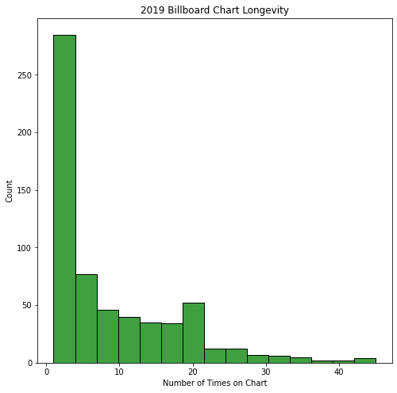

```python
import seaborn as sns
import matplotlib.pyplot as plt

fig, ax = plt.subplots(figsize=(8, 8))

sns.histplot(data=df_billboard_2019["Number of Times on Chart"], ax=ax, color='green')
plt.title("2019 Billboard Chart Longevity")
plt.show()
```

Our DataFrame looks great. Now, let's save it as a csv file:

```python
# saving this df:
# df_billboard_2019.to_csv('df_billboard_2019.csv')
```

To avoid having to rerun the above code (as it takes a long time to run) we can just read in this DataFrame while working on this project:

```python
df_billboard_2019 = pd.read_csv("df_billboard_2019.csv")
```

Before we make a predictive model for song popularity using this dataset, let's first construct our "post-pandemic" dataset. We will follow the same steps as before, except we will initially downselect our dataset to only contain songs from 2022.

```python
# downselecting for 2022 songs
billboard_df_2022 = billboard_df[(billboard_df["chart_date"].str.startswith("2022"))]
billboard_df_2022 = billboard_df_2022.sort_values(by=['song'])
# need to sort the df so it is in the order of the value_counts series

# finding number of times each song appears on the charts in 2022
longevity_series_22 = billboard_df_2022["song"].value_counts()

# making every song only appear once
billboard_df_2022 = billboard_df_2022.drop_duplicates(subset=['song'])

# list of each song and how many times it was on the charts in 2022
longevity_series_22
```

```
Big Energy                    43
Heat Waves                    43
Stay                          40
Ghost                         40
Shivers                       38
                              ..
Linus & Lucy                   1
Grow Up/Keep It On Speaker     1
Smoke One                      1
Gravity                        1
All Up In Your Mind            1
Name: song, Length: 630, dtype: int64
```

```python
from pandas.api.types import CategoricalDtype

# sorting the dataframe to match the order of the longevity_series
cat_song_order = CategoricalDtype(
    longevity_series_22.index,
    ordered=True
)

billboard_df_2022['song'] = billboard_df_2022['song'].astype(cat_song_order)
billboard_df_2022 = billboard_df_2022.sort_values('song')

# creating variables of the desired order for songs and artists
desired_song_order_list_22 = billboard_df_2022["song"].values
desired_artist_order_list_22 = billboard_df_2022["performer"].values
```

```python
billboard_df_2022.head() # 2022 billboard data, now in order of most to least # of times on Chart in 2022
```

|  | chart_position | chart_date | song | performer | song_id | instance | time_on_chart | consecutive_weeks | previous_week | peak_position | worst_position | chart_debut | chart_url |
| --- | --- | --- | --- | --- | --- | --- | --- | --- | --- | --- | --- | --- | --- |
| 30631 | 11 | 2022-07-30 | Big Energy | Latto | Big EnergyLatto | 1.0 | 39 | 38.0 | 10.0 | 3 | 95 | 2021-11-06 | https://www.billboard.com/charts/hot-100/2022-07-30 |
| 107489 | 7 | 2022-07-23 | Heat Waves | Glass Animals | Heat WavesGlass Animals | 2.0 | 78 | 76.0 | 8.0 | 1 | 100 | 2021-01-16 | https://www.billboard.com/charts/hot-100/2022-07-23 |
| 257236 | 15 | 2022-07-23 | Stay | The Kid LAROI & Justin Bieber | StayThe Kid LAROI & Justin Bieber | 1.0 | 53 | 52.0 | 16.0 | 1 | 21 | 2021-07-24 | https://www.billboard.com/charts/hot-100/2022-07-23 |
| 93138 | 6 | 2022-04-09 | Ghost | Justin Bieber | GhostJustin Bieber | 2.0 | 27 | 25.0 | 5.0 | 5 | 93 | 2021-04-03 | https://www.billboard.com/charts/hot-100/2022-04-09 |
| 242729 | 39 | 2022-07-02 | Shivers | Ed Sheeran | ShiversEd Sheeran | 1.0 | 41 | 40.0 | 31.0 | 4 | 39 | 2021-09-25 | https://www.billboard.com/charts/hot-100/2022-07-02 |

```python
len(desired_song_order_list_22)
```

```
630
```

```python
# using spotify's api to get this info

track_id_22_list = []

for track in desired_song_order_list_22:
  try:
    track_json = sp.search(q='track:' + track, type='track')
    track_id = track_json['tracks']['items'][0]['id']
    track_id_22_list.append(track_id)
  except IndexError:
    track_id = "N/A"
    print(track)
```

```
Don't Think Jesus
Christmas Tree Farm (Old Timey Version)
I'd Do Anything To Make You Smile
Oklahoma Smoke Show
```

```python
print(len(longevity_series_22))
longevity_series_22 = longevity_series_22.drop(labels=["Don't Think Jesus", "Christmas Tree Farm (Old Timey Version)", "I'd Do Anything To Make You Smile", "Oklahoma Smoke Show"])
print(len(longevity_series_22))
```

```
630
626
```

```python
# creating a dataframe for the spotify api info on each of these songIDs
df_billboard_2022 = pd.DataFrame(columns=['name', 'album', 'artist', 'release_date', 'length', 'popularity', 'explicit', 'acousticness',
                                            'danceability', 'energy', 'instrumentalness', 'liveness', 'loudness', 'speechiness',
                                           'tempo', 'time_signature', 'key', 'mode', 'valence'])

for id in track_id_22_list:
  track_list = getTrackFeatures(id)
  df = pd.DataFrame(data=[track_list], columns=['name', 'album', 'artist', 'release_date', 'length', 'popularity', 'explicit', 'acousticness',
                                            'danceability', 'energy', 'instrumentalness', 'liveness', 'loudness', 'speechiness',
                                           'tempo', 'time_signature', 'key', 'mode', 'valence'])

  df_billboard_2022 = pd.concat([df_billboard_2022, df], ignore_index=True)

df_billboard_2022.head()
```

|  | name | album | artist | release_date | length | popularity | explicit | acousticness | danceability | energy | instrumentalness | liveness | loudness | speechiness | tempo | time_signature | key | mode | valence |
| --- | --- | --- | --- | --- | --- | --- | --- | --- | --- | --- | --- | --- | --- | --- | --- | --- | --- | --- | --- |
| 0 | Big Energy | Big Energy | Latto | 2021-09-24 | 173182 | 76 | True | 0.0514 | 0.935 | 0.807 | 0 | 0.3490 | -3.838 | 0.1140 | 106.017 | 4 | 11 | 0 | 0.813 |
| 1 | Heat Waves | Heat Waves | Glass Animals | 2020-06-29 | 238805 | 83 | False | 0.4400 | 0.761 | 0.525 | 0.000007 | 0.0921 | -6.900 | 0.0944 | 80.870 | 4 | 11 | 1 | 0.531 |
| 2 | Habits (Stay High) | Queen Of The Clouds | Tove Lo | 2014-01-01 | 209160 | 73 | False | 0.0702 | 0.729 | 0.650 | 0.000067 | 0.0829 | -3.539 | 0.0313 | 110.020 | 4 | 5 | 1 | 0.347 |
| 3 | Ghost Town | ye | Kanye West | 2018-06-01 | 271386 | 77 | True | 0.0969 | 0.573 | 0.545 | 0 | 0.3290 | -4.247 | 0.0288 | 83.378 | 4 | 7 | 0 | 0.297 |
| 4 | Shivers | Shivers | Ed Sheeran | 2021-09-13 | 207853 | 76 | False | 0.2810 | 0.788 | 0.859 | 0 | 0.0424 | -2.724 | 0.0856 | 141.020 | 4 | 2 | 1 | 0.822 |

```python
df_billboard_2022 = df_billboard_2022.dropna()
len(df_billboard_2022)
```

```
626
```

```python
df_billboard_2022["Number of Times on Chart"] = longevity_series_22.values
```

```python
df_billboard_2022.head()
```

|  | name | album | artist | release_date | length | popularity | explicit | acousticness | danceability | energy | instrumentalness | liveness | loudness | speechiness | tempo | time_signature | key | mode | valence | Number of Times on Chart |
| --- | --- | --- | --- | --- | --- | --- | --- | --- | --- | --- | --- | --- | --- | --- | --- | --- | --- | --- | --- | --- |
| 0 | Big Energy | Big Energy | Latto | 2021-09-24 | 173182 | 76 | True | 0.0514 | 0.935 | 0.807 | 0 | 0.3490 | -3.838 | 0.1140 | 106.017 | 4 | 11 | 0 | 0.813 | 43 |
| 1 | Heat Waves | Heat Waves | Glass Animals | 2020-06-29 | 238805 | 83 | False | 0.4400 | 0.761 | 0.525 | 0.000007 | 0.0921 | -6.900 | 0.0944 | 80.870 | 4 | 11 | 1 | 0.531 | 43 |
| 2 | Habits (Stay High) | Queen Of The Clouds | Tove Lo | 2014-01-01 | 209160 | 73 | False | 0.0702 | 0.729 | 0.650 | 0.000067 | 0.0829 | -3.539 | 0.0313 | 110.020 | 4 | 5 | 1 | 0.347 | 40 |
| 3 | Ghost Town | ye | Kanye West | 2018-06-01 | 271386 | 77 | True | 0.0969 | 0.573 | 0.545 | 0 | 0.3290 | -4.247 | 0.0288 | 83.378 | 4 | 7 | 0 | 0.297 | 40 |
| 4 | Shivers | Shivers | Ed Sheeran | 2021-09-13 | 207853 | 76 | False | 0.2810 | 0.788 | 0.859 | 0 | 0.0424 | -2.724 | 0.0856 | 141.020 | 4 | 2 | 1 | 0.822 | 38 |

```python
# saving this df:
df_billboard_2022.to_csv('df_billboard_2022.csv')
```

We can now just read in this DataFrame while working on this project:

```python
df_billboard_2022 = pd.read_csv("df_billboard_2022.csv")
```

# Step 2: Creating Predictive Models Using These DataFrames

We are going to first construct a model that will predict the number of times a song appeared on the Billboard Top 100 Chart in 2019 using the DataFrame *df_billboard_2019*. We will need to determine which features are the most important in predicting this label in order to get an accurate model. Once we know these features, we can best predict the number of times a song appeared on the Charts. We will repeat this whole process for the DataFrame *df_billboard_2022*, and see how the p-values have changed before and after the pandemic.

Let's start with the pre-pandemic data. We will train k-nearest neighbors regression models to predict the number of times a song was on the Charts in 2019 for different values of k. We will validate our model using 10-fold cross validation, and calculate the training and validation MAE of each model to determine the best value for k.

There are many variables in our datasets, some of which will not be very helpful in constructing a predictive model. We must investigate which variables will act as the best features for predicting our label of "Number of Times on Chart". To do this, let's use a Python library known as statsmodels to calculate each quantitative variable's p-value.

```python
import statsmodels.api as sm

# making a copy of dataframe
df_billboard_2019_copy = df_billboard_2019.copy()

potential_features = ['length', 'popularity', 'acousticness', 'danceability',
                            'energy', 'instrumentalness', 'liveness', 'loudness',
                            'speechiness', 'tempo', 'time_signature', 'key', 'mode', 'valence']

# define predictor and response variables
y = df_billboard_2019_copy["Number of Times on Chart"]
x = df_billboard_2019_copy[potential_features]

# add constant to predictor variables
x = sm.add_constant(x)

# fit linear regression model
model = sm.OLS(y, x).fit()

p_vals = []

for x in range (0, 14):
  p_vals.append(model.pvalues[x])
  print(f"The p-value for {potential_features[x]} is {model.pvalues[x]}")
```

```
The p-value for length is 0.01913840003611477
The p-value for popularity is 0.027387017094701538
The p-value for acousticness is 5.1940228934844405e-11
The p-value for danceability is 0.09021632931923151
The p-value for energy is 0.9873908382078935
The p-value for instrumentalness is 0.04839219911699771
The p-value for liveness is 0.5517950995039411
The p-value for loudness is 0.032331565909685174
The p-value for speechiness is 0.015102938944052619
The p-value for tempo is 0.8884891710765106
The p-value for time_signature is 0.04408846110899298
The p-value for key is 0.37130985202204025
The p-value for mode is 0.2356982152183616
The p-value for valence is 0.6645892613643811
```

A p-value less than 0.05 is considered to be statistically significant. Let's iterate through the p_vals list we just created and extract only the p-values less than 0.05.

```python
desired_features = []

for p in range(0, 14):
  if p_vals[p] < 0.05:
    desired_features.append(potential_features[p])
    print(f"{potential_features[p]}: {p_vals[p]}")
```

```
length: 0.01913840003611477
popularity: 0.027387017094701538
acousticness: 5.1940228934844405e-11
instrumentalness: 0.04839219911699771
loudness: 0.032331565909685174
speechiness: 0.015102938944052619
time_signature: 0.04408846110899298
```

Now that we know which variables have the most statistically significant p-values, we can use these as features for our model to predict "Number of Times on Chart".

```python
from sklearn.feature_extraction import DictVectorizer
from sklearn.preprocessing import StandardScaler
from sklearn.neighbors import KNeighborsRegressor
from sklearn.pipeline import Pipeline
from sklearn.model_selection import cross_validate
import matplotlib.pyplot as plt
from sklearn.model_selection import cross_val_score


# get the features (in dict format) and the labels
# (do not split into training and validation sets)
x_dict = df_billboard_2019_copy[desired_features].to_dict(orient="records")
y = df_billboard_2019_copy["Number of Times on Chart"]

# specify the pipeline
vec = DictVectorizer(sparse=False)
scaler = StandardScaler()

# options for k
k_opts = [i for i in range(1, 50, 1)]

# empty list of validation errors
validation_maes = []

# empty list of training errors
training_maes = []

# creating each model, fitting to training set, predicting y_val, calculating MAE, and appending to list
for k in k_opts:
    model = KNeighborsRegressor(n_neighbors=k)
    pipeline = Pipeline([("vectorizer", vec), ("scaler", scaler), ("fit", model)])
    scores = cross_validate(pipeline, x_dict, y, cv=10, scoring="neg_mean_absolute_error", return_train_score=True)
    average_validation_mae = -scores["test_score"].mean()
    validation_maes.append(average_validation_mae)
    average_training_mae = -scores["train_score"].mean()
    training_maes.append(average_training_mae)
```

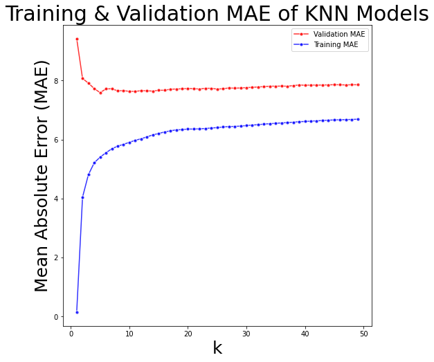

```python
# plotting
fig, ax = plt.subplots(1, 1, figsize=(8, 8))
ax.plot(k_opts, validation_maes, marker="o",linestyle="-", markersize=5, color="red", markeredgecolor="white", alpha=0.8)
ax.plot(k_opts, training_maes, marker="o",linestyle="-", markersize=5, color="blue", markeredgecolor="white", alpha=0.8)
ax.set_xlabel('k', size=25)
ax.set_ylabel('Mean Absolute Error (MAE)', size=25)
ax.set_title('Training & Validation MAE of KNN Models', size=30)
ax.legend(['Validation MAE', 'Training MAE'])
```

We can see from the graph that the training MAE is smaller than the validation MAE. This makes sense because it is harder for our model to predict data it has not seen before than data it has already seen. As the value of k increases, the training MAE hovers around 6, while the validation MAE hovers around 8. This means that our model is typically around 6 weeks off when predicting the number of weeks a song has been on the Top 100 Charts for data it has already seen, and typically around 8 weeks off for data it has not yet seen. We will continue to tweak our model in the coming weeks in order to make it more accurate.

Now, let's determine the best value for k (i.e., the value of k that minimizes the validation MAE):

```python
vec = DictVectorizer(sparse=False)
scaler = StandardScaler()

x_dict = df_billboard_2019_copy[desired_features].to_dict(orient="records")
y = df_billboard_2019_copy["Number of Times on Chart"]
```

```python
def get_cv_error(k):
    model = KNeighborsRegressor(n_neighbors=k)
    pipeline = Pipeline([("vectorizer", vec), ("scaler", scaler), ("fit", model)])
    mae = np.mean(-cross_val_score(
        pipeline, x_dict, y,
        cv=10, scoring="neg_mean_absolute_error"
    ))
    return mae
```

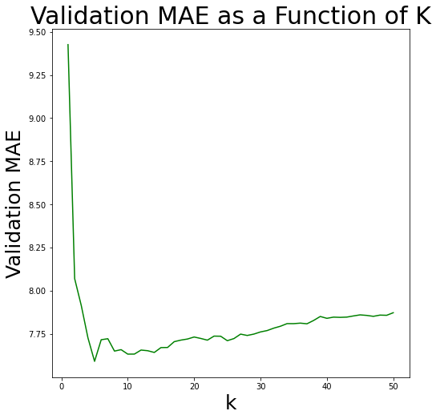

```python
from matplotlib import pyplot as plt

ks = pd.Series(range(1, 51))
ks.index = range(1, 51)
test_errs = ks.apply(get_cv_error)

test_errs.plot.line(figsize=(8,8), color='green')
plt.title("Validation MAE as a Function of K", size=30)
plt.xlabel("k", size=25)
plt.ylabel("Validation MAE", size=25)
```

```python
print(f"The best value for k is {test_errs.idxmin()}, where the Validation MAE is {test_errs[test_errs.idxmin()]}.")
```

```
The best value for k is 5, where the Validation MAE is 7.592099418297197.
```

# Plan For Milestone 3

We will continue working on improving the various predictive models we are creating so that they are as accurate as possible. As Spotify continues to update the "Today's Top Hits" playlist, we will keep pulling this new information and putting each new week's data into a DataFrame. These will be used to make a predictive model that will be compared to the model made from the Spotify Tracks Dataset.

Once we make a predictive model on the post-pandemic Billboard Chart data, we will begin analyzing the importance of the various features in predicting "Number of Times on Chart" and how their importance has changed from 2019 to 2022. Finally, we will be able to make conclusions from these comparisons.

```python
%%shell
jupyter nbconvert --to html /content/Milestone3.ipynb
```

```
[NbConvertApp] Converting notebook /content/Milestone3.ipynb to html
[NbConvertApp] Writing 638039 bytes to /content/Milestone3.html
```